# Sesión 05 · Estadística descriptiva

Notebook de práctica — Introducción a R, semestre 2027-1

Autor/a

Dra. Yalbi Itzel Balderas-Martínez

## Antes de empezar

Este notebook repasa, **en R y función por función**, lo que se vio en la presentación de estadística descriptiva. Lo vas a correr tú, bloque por bloque.

Cada bloque gris de código se puede ejecutar por separado. Corre uno, mira lo que contesta R, y sigue. Los bloques **dependen unos de otros**: corre en orden. Si te saltas uno, el siguiente dará `objeto no encontrado`.

Las preguntas y los ejercicios traen su respuesta debajo, plegada bajo un desplegable. **Inténtalo antes de abrirla**: leer la respuesta no enseña nada, escribirla sí.

```r
# library() carga un paquete que ya está instalado, para poder usar sus
# funciones en esta sesión de R.
library(ggplot2) # para hacer gráficas
library(MASS)    # trae la tabla birthwt (peso al nacer) y la tabla Animals
```

Si la primera línea da error, falta instalar el paquete. Corre `install.packages("ggplot2")` **una vez** y vuelve aquí.

**Nota**

Si algo falla, mira el anexo de errores frecuentes del manual antes de preguntar: los errores más comunes de R vienen ahí con su arreglo.

### Las funciones nuevas de hoy

| Función | Para qué sirve |
| --- | --- |
| `table()` | cuenta cuántas veces aparece cada valor |
| `sort()` | ordena un vector de menor a mayor |
| `mean()`, `median()` | media y mediana |
| `var()`, `sd()` | varianza y desviación estándar |
| `quantile()`, `IQR()` | cuartiles y rango intercuartílico |
| `summary()` | mínimo, cuartiles, media y máximo de una vez |
| `tapply()` | aplica un resumen **por grupo** |
| `reorder()` | ordena las categorías de una gráfica según un número |
| `coord_polar()` | convierte barras en un pastel |
| `coord_cartesian()` | acerca el eje de una gráfica |
| `scale_x_log10()` | pone un eje en escala logarítmica |

## 1. Qué tipo de dato es

Antes de calcular o graficar, la primera pregunta es **qué tipo de variable** tienes. El tipo decide qué resumen y qué gráfica le quedan.

| Tipo | Qué es | Ejemplos |
| --- | --- | --- |
| **Categórica nominal** | categorías sin orden | sexo, país, si la madre fumó |
| **Categórica ordinal** | categorías con orden | tamaño de un tatuaje: pequeño, mediano, grande; un resultado de 1 (malo) a 4 (excelente) |
| **Numérica discreta** | se cuenta: 0, 1, 2… | número de consultas prenatales, número de hijos |
| **Numérica continua** | se mide y admite decimales | peso al nacer, presión arterial, concentración de una hormona |

Sentido común: si tiene sentido sacar el promedio, es numérica; si solo tiene sentido contar cuántos hay de cada una, es categórica.

Un caso engañoso: una escala de 1 a 4 **parece** número, pero es ordinal. La distancia entre «malo» (1) y «regular» (2) no tiene por qué ser igual a la que hay entre «bueno» (3) y «excelente» (4).

### La tabla de hoy: `birthwt`

`birthwt` reúne 189 nacimientos de un hospital de Springfield, Estados Unidos, en 1986. Viene en el paquete `MASS`, así que no hay nada que descargar.

```r
# str() muestra la ESTRUCTURA de una tabla: cuántas filas (obs.) y columnas
# (variables) tiene, y de qué tipo es cada columna.
str(birthwt)
```

```
'data.frame':   189 obs. of  10 variables:
 $ low  : int  0 0 0 0 0 0 0 0 0 0 ...
 $ age  : int  19 33 20 21 18 21 22 17 29 26 ...
 $ lwt  : int  182 155 105 108 107 124 118 103 123 113 ...
 $ race : int  2 3 1 1 1 3 1 3 1 1 ...
 $ smoke: int  0 0 1 1 1 0 0 0 1 1 ...
 $ ptl  : int  0 0 0 0 0 0 0 0 0 0 ...
 $ ht   : int  0 0 0 0 0 0 0 0 0 0 ...
 $ ui   : int  1 0 0 1 1 0 0 0 0 0 ...
 $ ftv  : int  0 3 1 2 0 0 1 1 1 0 ...
 $ bwt  : int  2523 2551 2557 2594 2600 2622 2637 2637 2663 2665 ...
```

Las columnas que se usan hoy:

| Columna | Qué es | Cómo está guardada |
| --- | --- | --- |
| `bwt` | peso del bebé al nacer, en gramos | número |
| `smoke` | si la madre fumó en el embarazo: 0 = no, 1 = sí | número |
| `race` | raza de la madre: 1 = blanca, 2 = negra, 3 = otra | número |
| `ftv` | consultas médicas en el primer trimestre | número |
| `age` | edad de la madre, en años | número |

**TipEjercicio 1 · R dice «número», pero ¿qué tipo de variable es?**

`str()` dice `int` (número entero) para las cinco columnas. Para cada una, ¿qué tipo de variable es **en realidad**: nominal, ordinal, discreta o continua?

### Respuesta

| Columna | Tipo real | Por qué |
| --- | --- | --- |
| `bwt` | numérica continua | se mide; el promedio tiene sentido |
| `smoke` | categórica nominal | el 0 y el 1 son etiquetas de «no» y «sí» |
| `race` | categórica nominal | el 1, 2 y 3 son etiquetas; sacar su promedio no significa nada |
| `ftv` | numérica discreta | se cuenta: 0, 1, 2… consultas |
| `age` | numérica continua | se mide en años (aquí, redondeada a enteros) |

Por eso, en el bloque de cajas (sección 6), `smoke` se convierte en factor antes de graficar.

**Importante**

Lo que R guarda **no** siempre es lo que la variable es. Un 0 y un 1 pueden ser un número o las etiquetas de «no» y «sí»: eso lo decide quien conoce los datos, no `str()`.

## 2. Mostrar categorías: pastel o barras

### Los datos: centrales nucleares por país

Doce países y cuántas centrales nucleares tenían en los años ochenta (por eso aparecen la Unión Soviética, Checoslovaquia y las dos Alemanias).

```r
# data.frame() arma una tabla a partir de vectores del mismo largo.
# Cada vector se vuelve una columna.
nucleares <- data.frame(
  pais = c("Canadá", "Checoslovaquia", "Alemania Oriental", "Francia",
           "Japón", "Corea del Sur", "Unión Soviética", "España", "Suecia",
           "Reino Unido", "Estados Unidos", "Alemania Occidental"),
  n = c(22, 13, 10, 52, 43, 9, 73, 10, 12, 41, 119, 23)
)

nucleares # al escribir solo el nombre, R muestra la tabla
```

```
                  pais   n
1               Canadá  22
2       Checoslovaquia  13
3    Alemania Oriental  10
4              Francia  52
5                Japón  43
6        Corea del Sur   9
7      Unión Soviética  73
8               España  10
9               Suecia  12
10         Reino Unido  41
11      Estados Unidos 119
12 Alemania Occidental  23
```

Fuente: The Open University, *Exploring data: graphs and numerical summaries*, OpenLearn, sección 2.1.

### Un pastel es una barra enrollada

En `ggplot2` no existe `geom_pie()`. Un pastel se hace con **una sola barra apilada** y luego se «enrolla» en círculo con `coord_polar()`.

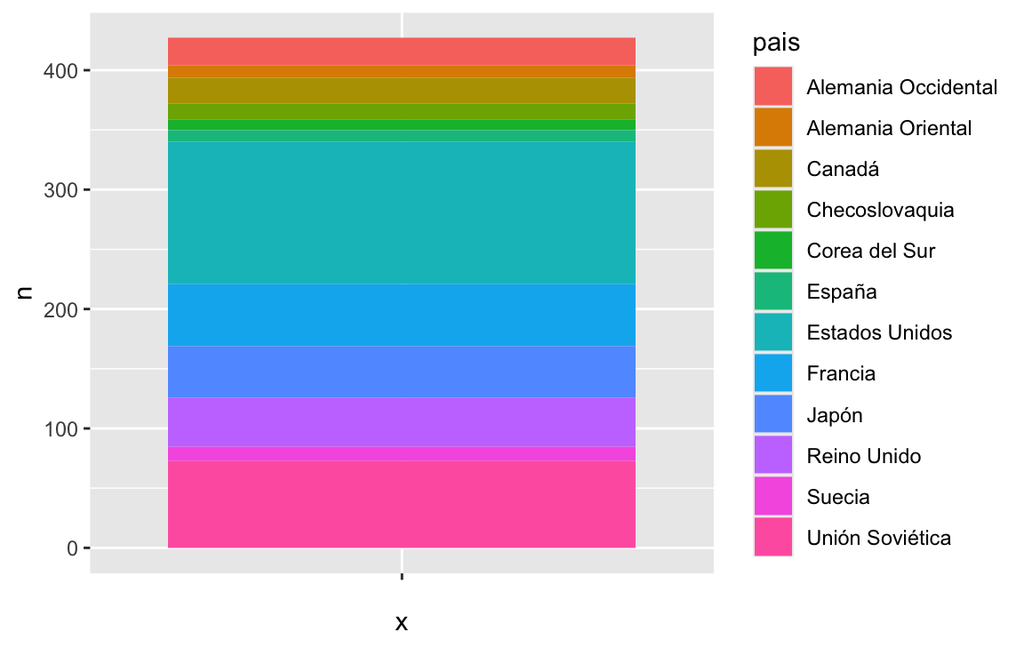

```r
# Paso 1: una sola barra apilada.
# x = "" pone TODAS las filas en la misma posición del eje x (una sola barra);
# y = n es la altura de cada pedazo; fill = pais le da un color a cada país.
ggplot(nucleares, aes(x = "", y = n, fill = pais)) +
  geom_col() # geom_col() dibuja barras con la altura que ya trae la tabla
```

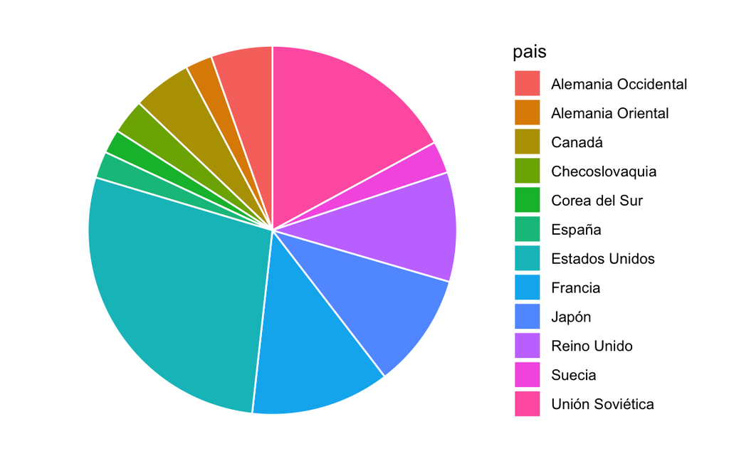

```r
# Paso 2: la misma barra, enrollada.
# coord_polar(theta = "y") convierte la altura (eje y) en ángulo.
ggplot(nucleares, aes(x = "", y = n, fill = pais)) +
  geom_col(width = 1, color = "white") + # width = 1 quita el agujero del centro
  coord_polar(theta = "y") +
  theme_void() # quita ejes y fondo, que en un pastel no significan nada
```

**Pregunta:** con este pastel, ¿qué país tiene más centrales: **Japón** o el **Reino Unido**? Contesta antes de abrir la respuesta.

**TipRespuesta: Japón, con 43 contra 41**

Casi nadie puede decirlo con seguridad viendo el pastel. Falla por dos razones:

- Hay **demasiadas categorías**: doce colores obligan a ir y venir a la leyenda.
- El ojo compara mal **ángulos y áreas**, y compara bien **longitudes que empiezan en la misma base** (Cleveland y McGill, 1984).

Las barras ordenadas lo contestan de un vistazo. Córrelas en el bloque siguiente.

### Barras ordenadas con `reorder()`

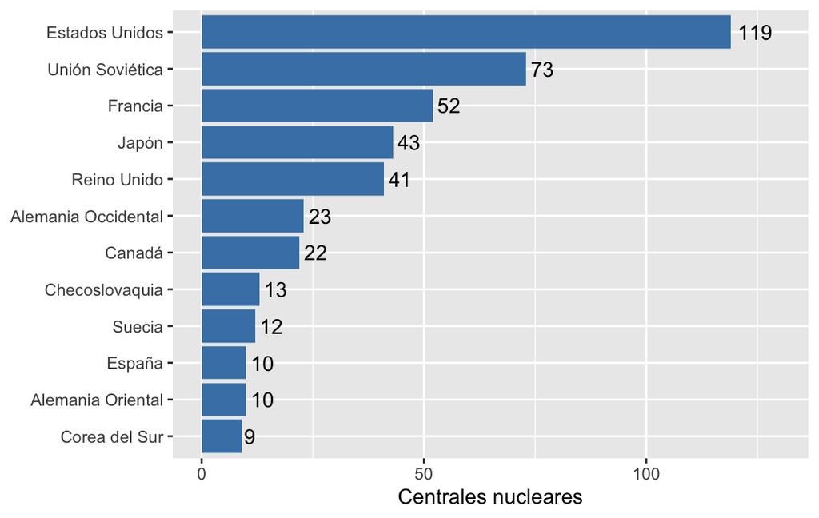

```r
# reorder(pais, n) ordena los países SEGÚN su número de centrales.
# Sin reorder(), ggplot2 los pone en orden alfabético.
# Al poner el país en y, las barras quedan acostadas y los nombres se leen.
ggplot(nucleares, aes(x = n, y = reorder(pais, n))) +
  geom_col(fill = "steelblue") +           # fill FIJA un color: va fuera de aes()
  geom_text(aes(label = n), hjust = -0.2) + # escribe el número junto a cada barra
  xlim(0, 130) + # alarga el eje x para que quepa el 119 de Estados Unidos
  labs(x = "Centrales nucleares", y = NULL) # y = NULL quita el título del eje y
```

**TipEjercicio 2 · quita el `reorder()`**

Copia el bloque anterior y cambia `reorder(pais, n)` por solo `pais`. ¿Qué cambió? ¿Cuál de las dos versiones contesta más rápido «quién tiene más»?

### Respuesta

```r
ggplot(nucleares, aes(x = n, y = pais)) +
  geom_col(fill = "steelblue")
```

Los países quedan en orden alfabético (de abajo hacia arriba). Para saber quién tiene más hay que recorrer todas las barras; ordenadas, basta ver la primera.

### Cuándo sí funciona un pastel

Con **pocas categorías** y cuando el mensaje es «qué parte del total». Ejemplo: a 55 pacientes se les quitó un tatuaje; 30 eran grandes, 16 medianos y 9 pequeños.

```r
# Los tres conteos, tomados de la tabla de 55 pacientes
# (OpenLearn, sección 2.7; fuente original: Lunn y McNeil, 1988).
tatuajes <- data.frame(
  tamano = c("Grandes", "Medianos", "Pequeños"),
  n = c(30, 16, 9)
)
tatuajes
```

```
    tamano  n
1  Grandes 30
2 Medianos 16
3 Pequeños  9
```

**Pregunta:** el círculo completo mide 360°. A cada categoría le toca una parte **proporcional a su conteo**. ¿Cuántos grados le tocan a la rebanada de los tatuajes **grandes**? Calcúlalo con R como calculadora antes de abrir la respuesta.

**TipRespuesta: 196.4°**

$$\text{ángulo} = 360° \times \frac{30}{30 + 16 + 9} = 360° \times \frac{30}{55} \approx 196.4°$$

En R, para las tres categorías a la vez:

```r
# sum(tatuajes$n) es el total: 55.
# R hace la cuenta para cada fila del vector n.
tatuajes$grados <- 360 * tatuajes$n / sum(tatuajes$n)
tatuajes
```

Los grandes ocupan **más de la mitad** del círculo, y eso sí se ve de un vistazo en el pastel del bloque siguiente.

```r
tatuajes$grados <- 360 * tatuajes$n / sum(tatuajes$n)
tatuajes
```

```
    tamano  n    grados
1  Grandes 30 196.36364
2 Medianos 16 104.72727
3 Pequeños  9  58.90909
```

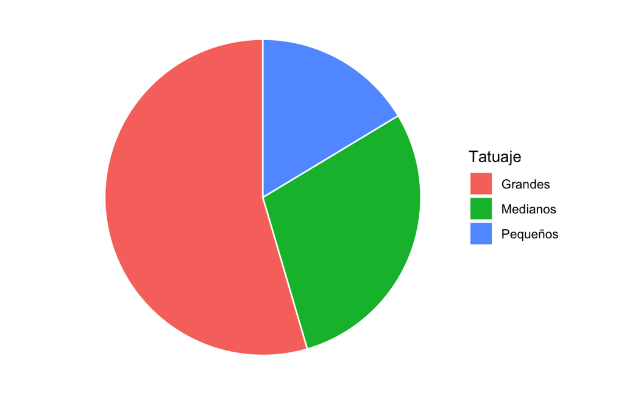

```r
ggplot(tatuajes, aes(x = "", y = n, fill = tamano)) +
  geom_col(width = 1, color = "white") +
  coord_polar(theta = "y") +
  labs(fill = "Tatuaje") + # título de la leyenda
  theme_void()
```

Si se usa pastel: **plano**, con **pocas rebanadas**, y nunca en 3D. En la presentación se vio por qué: en perspectiva, lo que queda al frente se ve más grande que lo que queda atrás, aunque el dato sea el mismo.

## 3. El eje que no empieza en cero

Los mismos dos datos, Japón (43) y el Reino Unido (41), graficados dos veces.

```r
# Del data frame, solo las filas de Japón y Reino Unido.
# %in% pregunta, para cada país, si está en la lista: da TRUE o FALSE,
# y [ ] se queda con las filas TRUE (selección por condición, sesión 02).
dos_paises <- nucleares[nucleares$pais %in% c("Japón", "Reino Unido"), ]
dos_paises
```

```
          pais  n
5        Japón 43
10 Reino Unido 41
```

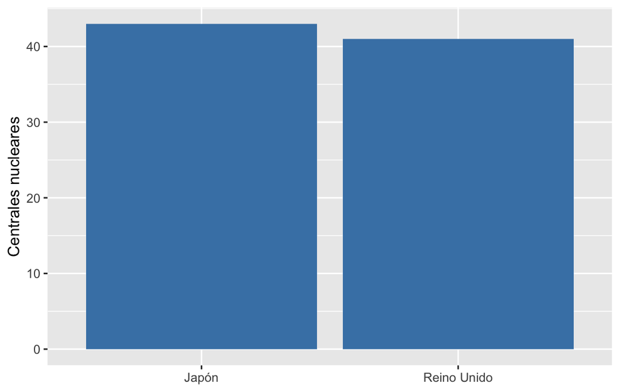

```r
# Versión 1: el eje empieza en cero (lo que ggplot2 hace solo)
ggplot(dos_paises, aes(x = pais, y = n)) +
  geom_col(fill = "steelblue") +
  labs(x = NULL, y = "Centrales nucleares")
```

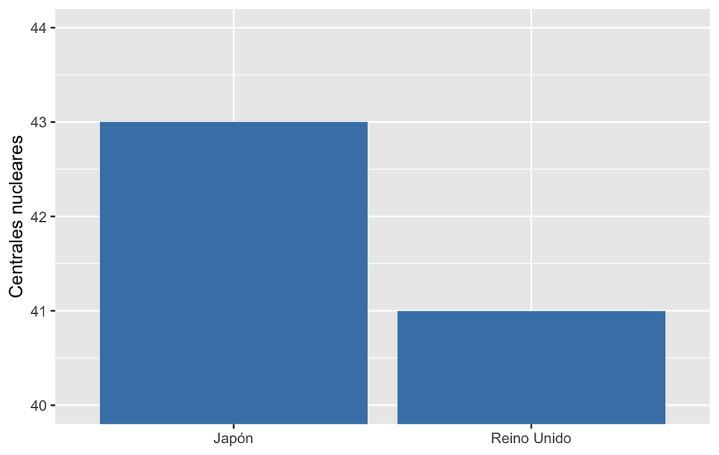

```r
# Versión 2: el mismo código, más una línea.
# coord_cartesian(ylim = ...) ACERCA el eje y: solo se ve de 40 a 44.
ggplot(dos_paises, aes(x = pais, y = n)) +
  geom_col(fill = "steelblue") +
  coord_cartesian(ylim = c(40, 44)) +
  labs(x = NULL, y = "Centrales nucleares")
```

En una barra, el ojo compara **longitudes**. Si la barra no empieza en cero, su longitud ya no es el dato.

### Cuánto exagera: el factor de mentira

Tufte (1983) propuso medir la distorsión así:

$$\text{factor de mentira} = \frac{\text{lo que muestra la gráfica}}{\text{lo que dicen los datos}}$$

Si vale **1**, la gráfica es fiel.

```r
# Lo que dicen los datos: Japón tiene 43 / 41 veces lo del Reino Unido
datos <- 43 / 41

# Lo que muestra la gráfica con el eje desde 40: la barra de Japón mide
# 43 - 40 = 3 y la del Reino Unido 41 - 40 = 1
grafica <- (43 - 40) / (41 - 40)

datos
```

```
[1] 1.04878
```

```r
grafica
```

```
[1] 3
```

```r
grafica / datos # el factor de mentira
```

```
[1] 2.860465
```

Los datos dicen «5 % más»; la gráfica muestra «el triple». El factor de mentira es de casi **2.9**.

**Importante**

En las **barras** el eje va desde cero siempre. En una gráfica de **puntos o de líneas** sí se puede acercar el eje, porque ahí se lee la **posición** y no la longitud.

## 4. Dos categorías a la vez: barras agrupadas

Fuerza laboral de Estados Unidos en 1986, en millones, por tipo de empleo y sexo.

```r
# rep(x, 2) repite x dos veces; rep(x, each = 7) repite CADA elemento 7 veces.
# Así se arman las 14 filas: 7 empleos para hombres y 7 para mujeres.
empleo <- data.frame(
  tipo = rep(c("Profesional", "Industrial", "Oficios", "Ventas", "Servicios",
               "Oficina", "Agrícola"), 2),
  sexo = rep(c("Hombres", "Mujeres"), each = 7),
  millones = c(15.00, 12.90, 12.30, 6.90, 5.80, 3.50, 2.90,
               11.60, 4.45, 1.25, 6.45, 9.60, 14.30, 0.65)
)
empleo
```

```
          tipo    sexo millones
1  Profesional Hombres    15.00
2   Industrial Hombres    12.90
3      Oficios Hombres    12.30
4       Ventas Hombres     6.90
5    Servicios Hombres     5.80
6      Oficina Hombres     3.50
7     Agrícola Hombres     2.90
8  Profesional Mujeres    11.60
9   Industrial Mujeres     4.45
10     Oficios Mujeres     1.25
11      Ventas Mujeres     6.45
12   Servicios Mujeres     9.60
13     Oficina Mujeres    14.30
14    Agrícola Mujeres     0.65
```

Fuente: Departamento del Trabajo de Estados Unidos, en The Open University, OpenLearn, sección 2.2.

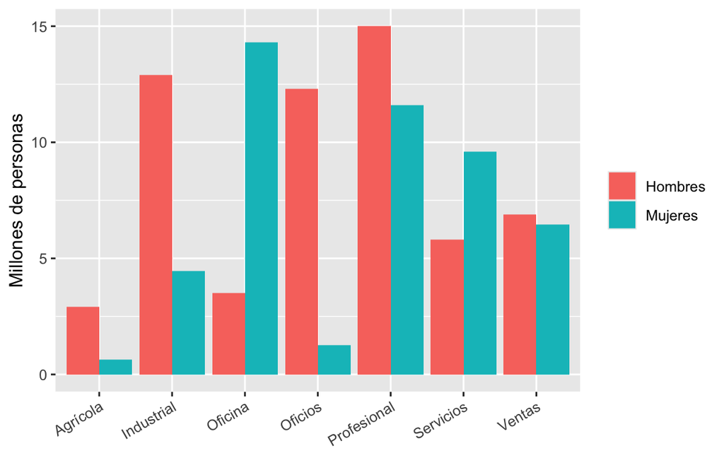

```r
# position = "dodge" pone las barras de cada sexo LADO A LADO.
# Sin él, ggplot2 las apila una encima de la otra.
ggplot(empleo, aes(x = tipo, y = millones, fill = sexo)) +
  geom_col(position = "dodge") +
  labs(x = NULL, y = "Millones de personas", fill = NULL) +
  theme(axis.text.x = element_text(angle = 30, hjust = 1)) # inclina los nombres
```

En **Ventas** las dos barras miden casi lo mismo: 6.90 millones de hombres y 6.45 de mujeres. Se comparan bien porque **empiezan en el mismo cero** y están **lado a lado**. En la versión 3D de la presentación, la fila de atrás arrancaba más arriba y parecía más alta: el 3D cambiaba la conclusión.

**TipEjercicio 3 · apiladas contra lado a lado**

Quita `position = "dodge"` y vuelve a correr. ¿Qué pregunta se contesta mejor con las barras apiladas, y cuál con las agrupadas?

### Respuesta

Apiladas contestan **«¿cuántas personas hay en total en cada empleo?»**: la altura completa de la barra es el total.

Agrupadas contestan **«¿hay más hombres o más mujeres en cada empleo?»**: las dos barras empiezan en cero y se comparan directo. En las apiladas, la barra de arriba no empieza en cero, y su longitud es difícil de comparar.

## 5. Resumir con números

Una tabla de 189 pesos no se puede leer de corrido. La estadística descriptiva la resume en **pocos números** (dónde está el centro, qué tanto se separan los datos) y en **una figura** (qué forma tienen).

```r
# El signo $ saca UNA columna de la tabla. Se guarda en un vector corto de
# nombre para no escribir birthwt$bwt cada vez.
bwt <- birthwt$bwt
length(bwt) # cuántos pesos hay
```

```
[1] 189
```

Para ver los cálculos a mano conviene empezar con pocos datos: siete pesos, tomados de siete filas de la tabla.

```r
# Primero se toman las filas 5, 40, 80, 110, 140, 170 y 189,
# y después sort() los ordena de menor a mayor.
siete <- sort(bwt[c(5, 40, 80, 110, 140, 170, 189)])
siete
```

```
[1] 1790 2353 2495 2600 3033 3459 3860
```

### Medidas de tendencia central: dónde está el centro

Tres formas de contestar «¿cuánto pesa un bebé típico?», cada una con una regla distinta:

| Medida | Regla | Sentido común |
| --- | --- | --- |
| **Media** | se suman los datos y se divide entre cuántos son | el punto donde una regla con los datos como pesas queda en equilibrio |
| **Mediana** | se ordenan los datos y se toma el de en medio | la mitad de los datos queda abajo y la otra mitad arriba |
| **Moda** | el valor que más se repite | lo más común |

#### Media

$$\bar{x} = \frac{x_1 + x_2 + \dots + x_n}{n}$$

```r
# A mano: sum() suma todos los datos y length() cuenta cuántos son
sum(siete) / length(siete)
```

```
[1] 2798.571
```

```r
# Con la función de R: da lo mismo
mean(siete)
```

```
[1] 2798.571
```

#### Mediana

- Si el número de datos $n$ es **impar**, es el dato de la posición $(n + 1)/2$. Con 7 datos, el 4.º.
- Si $n$ es **par**, es el promedio de los dos de en medio.

```r
siete[4]       # a mano: el cuarto de los siete, ya ordenados
```

```
[1] 2600
```

```r
median(siete)  # con la función de R
```

```
[1] 2600
```

```r
# Con un número PAR de datos, median() promedia los dos de en medio.
# Aquí, con 6 datos, promedia el 3.º y el 4.º: (3 + 4) / 2 = 3.5
median(c(1, 2, 3, 4, 5, 6))
```

```
[1] 3.5
```

#### Moda

R **no** tiene una función para la moda. Se saca contando con `table()`.

**Advertencia**

`mode()` existe, pero **no** da la moda: dice el tipo de objeto (`"numeric"`, `"character"`). No da error, así que el tropiezo pasa sin aviso.

```r
# table() cuenta cuántas madres tuvieron 0, 1, 2… consultas
consultas <- table(birthwt$ftv)
consultas
```

```
  0   1   2   3   4   6
100  47  30   7   4   1
```

```r
# which.max() dice DÓNDE está el conteo más alto; names() da la etiqueta
names(which.max(consultas))
```

```
[1] "0"
```

La moda es **0 consultas**: 100 de las 189 madres no tuvieron ninguna en el primer trimestre. Si dos valores empatan en lo más alto, la distribución es **bimodal**; si son tres, **trimodal**.

**TipEjercicio 4 · la edad de las madres**

Con la columna `age` de `birthwt`, calcula la media, la mediana y la moda de la edad de las madres. ¿Coinciden?

### Respuesta

```r
mean(birthwt$age)                    # 23.2 años
median(birthwt$age)                  # 23 años
names(which.max(table(birthwt$age))) # 20 años
```

No coinciden, y no tienen por qué: cada una sigue una regla distinta. La media y la mediana quedan muy cerca; la moda dice que la edad más frecuente fue 20.

```r
mean(birthwt$age)
```

```
[1] 23.2381
```

```r
median(birthwt$age)
```

```
[1] 23
```

```r
names(which.max(table(birthwt$age)))
```

```
[1] "20"
```

### Medidas de dispersión: qué tanto se separan

Dos grupos pueden tener **la misma media** y ser muy distintos: en uno todos se parecen y en el otro hay de todo. Las medidas de dispersión miden eso.

| Medida | Qué mide |
| --- | --- |
| **Rango** | del dato más pequeño al más grande |
| **Varianza** y **desviación estándar** | la distancia típica de los datos a la media |
| **Cuartiles** y **rango intercuartílico** | dónde cae la mitad central de los datos |

#### Rango

$$\text{rango} = \text{máximo} - \text{mínimo}$$

```r
min(bwt)            # el peso más bajo
```

```
[1] 709
```

```r
max(bwt)            # el más alto
```

```
[1] 4990
```

```r
max(bwt) - min(bwt) # el rango
```

```
[1] 4281
```

Es fácil de calcular, pero depende **solo de dos datos**: basta un valor extremo para cambiarlo.

```r
range(bwt)
```

```
[1]  709 4990
```

**Advertencia**

`range()` **no** da el rango: da el mínimo y el máximo. El rango es la resta, `max(bwt) - min(bwt)`.

#### Varianza, paso a paso

La varianza se construye en tres pasos. Se hacen con los siete pesos para ver cada número.

```r
# Paso 1. La distancia de cada dato a la media (se llama desviación).
# R resta la media a cada uno de los siete pesos.
desviaciones <- siete - mean(siete)
desviaciones
```

```
[1] -1008.5714  -445.5714  -303.5714  -198.5714   234.4286   660.4286  1061.4286
```

```r
# ¿Por qué no basta con sumarlas? Porque las negativas cancelan a las
# positivas, y la suma da CERO siempre (o casi: R muestra un número
# diminuto, como 9.1e-13, por cómo guarda los decimales).
sum(desviaciones)
```

```
[1] 9.094947e-13
```

```r
# Paso 2. Se elevan al cuadrado (^2): así todas quedan positivas.
cuadrados <- desviaciones^2
cuadrados
```

```
[1] 1017216.33  198533.90   92155.61   39430.61   54956.76  436165.90 1126630.61
```

```r
# Paso 3. Se suman y se dividen entre n - 1.
n <- length(siete)
sum(cuadrados) / (n - 1)
```

```
[1] 494181.6
```

```r
# La función de R da lo mismo
var(siete)
```

```
[1] 494181.6
```

$$s^2 = \frac{\sum_{i=1}^{n} (x_i - \bar{x})^2}{n - 1}$$

**¿Por qué entre $n - 1$ y no entre $n$?** Las distancias se miden contra la media **de la misma muestra**, que siempre queda en el centro de esos datos; por eso salen un poco más chicas que si se midieran contra la media verdadera de la población. Dividir entre $n - 1$ **compensa** esa diferencia. Se llama **corrección de Bessel** (Diez, Çetinkaya-Rundel y Barr, 2019). Con muestras grandes casi no cambia nada; con muestras chicas sí importa. `var()` y `sd()` ya dividen entre $n - 1$.

La varianza queda en **gramos al cuadrado**, que no se interpretan fácil. Por eso se usa su raíz.

#### Desviación estándar

$$s = \sqrt{s^2}$$

```r
sqrt(var(siete)) # la raíz cuadrada de la varianza
```

```
[1] 702.9805
```

```r
sd(siete)        # la función de R: da lo mismo
```

```
[1] 702.9805
```

Regresa a las **unidades de los datos** (gramos), y por eso sí se interpreta.

```r
mean(bwt) # media de los 189 pesos
```

```
[1] 2944.587
```

```r
sd(bwt)   # desviación estándar de los 189 pesos
```

```
[1] 729.2143
```

Un peso típico se aleja unos **729 g** de la media, que es de unos **2945 g**.

#### Cuartiles y rango intercuartílico

Los **cuartiles** parten los datos ordenados en cuatro partes iguales:

- $Q_1$ (percentil 25): debajo queda el 25 % de los datos
- $Q_2$ (percentil 50): es la mediana
- $Q_3$ (percentil 75): debajo queda el 75 %

El **rango intercuartílico** es $Q_3 - Q_1$: cuánto mide **la mitad central** de los datos. En inglés se abrevia IQR (*interquartile range*), y por eso la función de R se llama `IQR()`.

```r
# quantile() da los cuartiles; 0 % es el mínimo y 100 % el máximo
quantile(bwt)
```

```
  0%  25%  50%  75% 100%
 709 2414 2977 3487 4990
```

```r
IQR(bwt) # Q3 - Q1: 3487 - 2414
```

```
[1] 1073
```

`summary()` da casi todo de una vez:

```r
summary(bwt)
```

```
   Min. 1st Qu.  Median    Mean 3rd Qu.    Max.
    709    2414    2977    2945    3487    4990
```

### Qué resumen se mueve con los valores extremos

**Pregunta:** de los 189 pesos se quitan los **cuatro más bajos**. ¿Qué cambia más: la **media y la desviación estándar**, o la **mediana y el rango intercuartílico**? Apuesta antes de correr los bloques.

```r
# sort() ordena de menor a mayor, y [-(1:4)] quita las posiciones 1 a 4:
# los cuatro pesos más bajos.
bwt_sin4 <- sort(bwt)[-(1:4)]
length(bwt_sin4) # quedan 185
```

```
[1] 185
```

```r
# Los cuatro resúmenes, primero con los 189 pesos y después sin los cuatro
c(mediana = median(bwt), ric = IQR(bwt), media = mean(bwt), de = sd(bwt))
```

```
  mediana       ric     media        de
2977.0000 1073.0000 2944.5873  729.2143
```

```r
c(mediana = median(bwt_sin4), ric = IQR(bwt_sin4), media = mean(bwt_sin4),
  de = sd(bwt_sin4))
```

```
  mediana       ric     media        de
2977.0000 1102.0000 2985.5784  679.9907
```

**TipRespuesta: cambian más la media y la desviación estándar**

|  | Mediana | Rango intercuartílico | Media | Desviación estándar |
| --- | --- | --- | --- | --- |
| Los 189 pesos | 2977 | 1073 | 2945 | 729 |
| Sin los cuatro más bajos | 2977 | 1102 | 2986 | 680 |

La mediana **no se movió**. La media subió unos 41 g y la desviación estándar bajó unos 49 g.

La mediana y el rango intercuartílico son **robustos**: los valores extremos casi no los mueven. Regla práctica para una publicación: si la distribución es simétrica, se reporta **media y desviación estándar**; si está sesgada o tiene valores extremos, **mediana y rango intercuartílico**.

## 6. Mostrar distribuciones

### Histograma: cuántos datos caen en cada intervalo

Se parte el eje en **intervalos** y cada barra cuenta cuántos datos caen ahí. Una barra alta quiere decir muchos datos en ese intervalo. Sirve para ver la **forma** de la distribución.

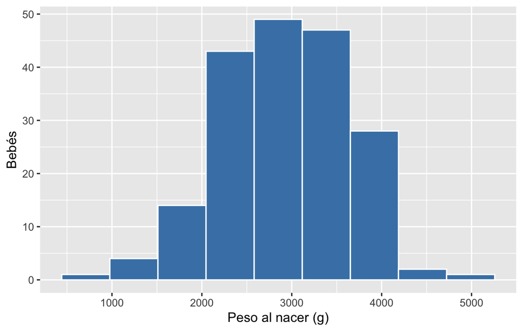

```r
# Para un histograma basta UNA variable numérica, en x.
# bins = 9 pide 9 intervalos.
ggplot(birthwt, aes(x = bwt)) +
  geom_histogram(bins = 9, fill = "steelblue", color = "white") +
  labs(x = "Peso al nacer (g)", y = "Bebés")
```

¿Por qué 9? La regla de Sturges (1926) propone $1 + \log_2 n$ intervalos. R la trae como función:

```r
nclass.Sturges(bwt) # con 189 datos: 9 intervalos
```

```
[1] 9
```

**TipEjercicio 5 · el número de intervalos cambia lo que se ve**

Haz el mismo histograma con `bins = 5` y con `bins = 40`. ¿Qué se pierde con pocos intervalos y qué estorba con muchos?

### Respuesta

```r
ggplot(birthwt, aes(x = bwt)) +
  geom_histogram(bins = 5, fill = "steelblue", color = "white")

ggplot(birthwt, aes(x = bwt)) +
  geom_histogram(bins = 40, fill = "steelblue", color = "white")
```

Con 5 intervalos se pierde la **forma**: todo se ve como un bloque. Con 40 se ve **ruido**: barras que suben y bajan solo porque hay pocos datos en cada intervalo. No hay un número correcto: hay que probar. `geom_histogram()` usa 30 si no se le dice nada, y avisa en un mensaje que conviene elegir otro.

### Forma de la distribución: simetría y sesgo

- **Simétrica**: las dos colas miden más o menos lo mismo. La media y la mediana quedan juntas.
- **Sesgo a la derecha**: la cola larga está a la derecha (muchos valores bajos y pocos muy altos). Ejemplos en salud: días de hospitalización, carga viral.
- **Sesgo a la izquierda**: la cola larga está a la izquierda. Ejemplo: edad de muerte en un país con buena esperanza de vida.

El sesgo se nombra por **el lado de la cola larga**, no por el lado del pico. Y la cola **jala a la media** hacia su lado.

Las consultas del primer trimestre (`ftv`) son un ejemplo real de sesgo a la derecha:

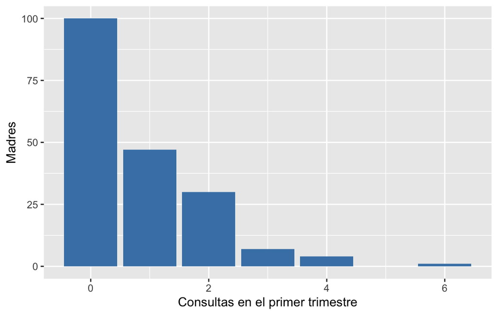

```r
# Como ftv es discreta (0, 1, 2…), en vez de histograma se usan barras:
# geom_bar() CUENTA cuántas filas hay de cada valor.
ggplot(birthwt, aes(x = ftv)) +
  geom_bar(fill = "steelblue") +
  labs(x = "Consultas en el primer trimestre", y = "Madres")
```

```r
mean(birthwt$ftv)   # la cola la jala hacia la derecha
```

```
[1] 0.7936508
```

```r
median(birthwt$ftv)
```

```
[1] 0
```

La media (0.79) queda **a la derecha** de la mediana (0): la cola la jala.

**Cuántas modas.** Una distribución con **dos picos** (bimodal) suele avisar que hay **dos grupos mezclados** en la misma variable; por ejemplo, la estatura de un grupo con hombres y mujeres juntos. En ese caso conviene separar por grupo antes de resumir: una sola media no describe a nadie.

### Diagrama de caja y bigotes

Resume la distribución en **cinco partes** (Tukey, 1977):

- La **caja** va de $Q_1$ a $Q_3$; la línea de adentro es la **mediana**.
- Los **bigotes** llegan hasta el dato más lejano que no pase de 1.5 veces el rango intercuartílico desde la caja.
- Los **puntos sueltos** son los valores atípicos: los que quedan más allá de los bigotes.

Su fuerza es **comparar grupos** lado a lado.

```r
# smoke está guardada como 0 y 1. factor() la convierte en dos grupos con
# nombre: levels dice qué valores hay y labels qué nombre lleva cada uno.
birthwt$fuma <- factor(birthwt$smoke, levels = c(0, 1),
                       labels = c("No fumó", "Fumó"))
table(birthwt$fuma) # cuántas madres hay en cada grupo
```

```
No fumó    Fumó
    115      74
```

**Pregunta:** en el bloque siguiente, ¿en qué grupo pesan menos los bebés? Fíjate en qué parte de la caja te basas para decirlo.

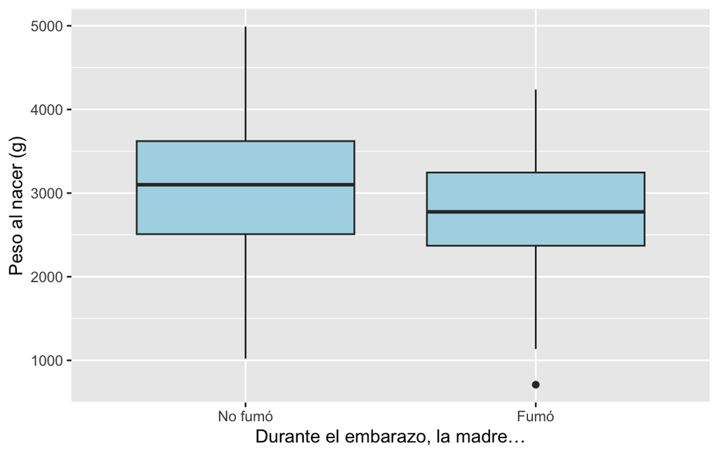

```r
# El grupo va en x y la variable numérica en y
ggplot(birthwt, aes(x = fuma, y = bwt)) +
  geom_boxplot(fill = "lightblue") +
  labs(x = "Durante el embarazo, la madre…", y = "Peso al nacer (g)")
```

**TipRespuesta: en el de las madres que fumaron**

La caja **completa** está más abajo: no solo la mediana, también $Q_1$ y $Q_3$. Los números, por grupo, salen con `tapply()`:

```r
# tapply(qué datos, en qué grupos, qué resumen)
tapply(birthwt$bwt, birthwt$fuma, median) # No fumó: 3100   Fumó: 2775.5
tapply(birthwt$bwt, birthwt$fuma, IQR)    # No fumó: 1112.5 Fumó: 875.25
```

Las cajas también **se enciman** en buena parte: hay bebés de madres que fumaron con peso alto, y al revés. Y lo que la caja **no** dice es si la diferencia se debe al tabaco o a otra cosa: eso ya no es estadística descriptiva, sino una prueba de hipótesis, que es otro tema.

**NotaLa función `tapply()`**

`tapply()` aplica un resumen **por grupo**. Lleva tres argumentos, en este orden:

1. **qué datos** se resumen (una columna numérica);
2. **en qué grupos** se parten (una columna categórica);
3. **qué resumen** se aplica (el nombre de una función, sin paréntesis).

```r
# Media del peso al nacer en cada grupo
tapply(birthwt$bwt, birthwt$fuma, mean)
```

```
 No fumó     Fumó
3055.696 2771.919
```

```r
# Cuántos bebés hay en cada grupo
tapply(birthwt$bwt, birthwt$fuma, length)
```

```
No fumó    Fumó
    115      74
```

**TipEjercicio 6 · peso al nacer según la raza de la madre**

1. Convierte `race` en factor, con las etiquetas `"Blanca"`, `"Negra"` y `"Otra"` para los valores 1, 2 y 3.
2. Haz un diagrama de caja del peso al nacer por raza.
3. Con `tapply()`, calcula la mediana de cada grupo.

### Respuesta

```r
birthwt$raza <- factor(birthwt$race, levels = c(1, 2, 3),
                       labels = c("Blanca", "Negra", "Otra"))

ggplot(birthwt, aes(x = raza, y = bwt)) +
  geom_boxplot(fill = "lightblue") +
  labs(x = "Raza de la madre", y = "Peso al nacer (g)")

tapply(birthwt$bwt, birthwt$raza, median)
```

Las medianas son 3062 g (blanca), 2849 g (negra) y 2835 g (otra). Si olvidas el paso 1 y usas `race` directo, ggplot2 la lee como número y dibuja **una sola caja** con un aviso: por eso se convierte primero en factor.

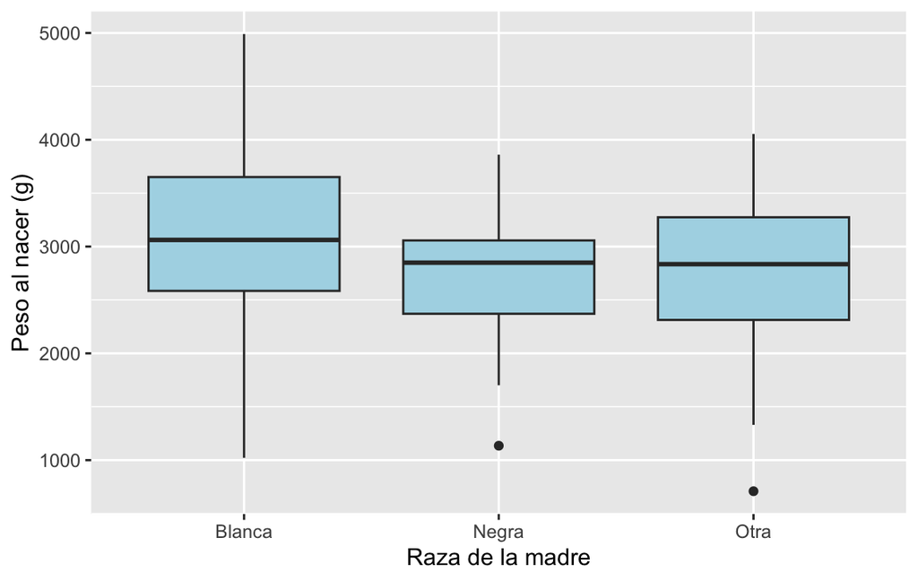

```r
birthwt$raza <- factor(birthwt$race, levels = c(1, 2, 3),
                       labels = c("Blanca", "Negra", "Otra"))

ggplot(birthwt, aes(x = raza, y = bwt)) +
  geom_boxplot(fill = "lightblue") +
  labs(x = "Raza de la madre", y = "Peso al nacer (g)")
```

```r
tapply(birthwt$bwt, birthwt$raza, median)
```

```
Blanca  Negra   Otra
  3062   2849   2835
```

## 7. Una variable numérica y una categórica, con datos reales

### Bebés con síndrome de dificultad respiratoria

Peso al nacer (kg) de 50 bebés con síndrome de dificultad respiratoria idiopática grave (SIRDS, por sus siglas en inglés: *severe idiopathic respiratory distress syndrome*), y si murieron o sobrevivieron.

```r
# Los primeros 27 pesos son de bebés que murieron; los últimos 23, de los que
# sobrevivieron. rep() escribe cada etiqueta las veces que hace falta.
sirds <- data.frame(
  peso = c(1.050, 1.175, 1.230, 1.310, 1.500, 1.600, 1.720, 1.750, 1.770, 2.275,
           2.500, 1.030, 1.100, 1.185, 1.225, 1.262, 1.295, 1.300, 1.550, 1.820,
           1.890, 1.940, 2.200, 2.270, 2.440, 2.560, 2.730,
           1.130, 1.575, 1.680,
           1.760, 1.930, 2.015, 2.090, 2.600, 2.700, 2.950, 3.160, 3.400, 3.640,
           2.830, 1.410, 1.715, 1.720, 2.040, 2.200, 2.400, 2.550, 2.570, 3.005),
  desenlace = rep(c("Murió", "Sobrevivió"), times = c(27, 23))
)
table(sirds$desenlace)
```

```
     Murió Sobrevivió
        27         23
```

Fuente: van Vliet y Gupta (1973), en The Open University, OpenLearn, sección 2.3.

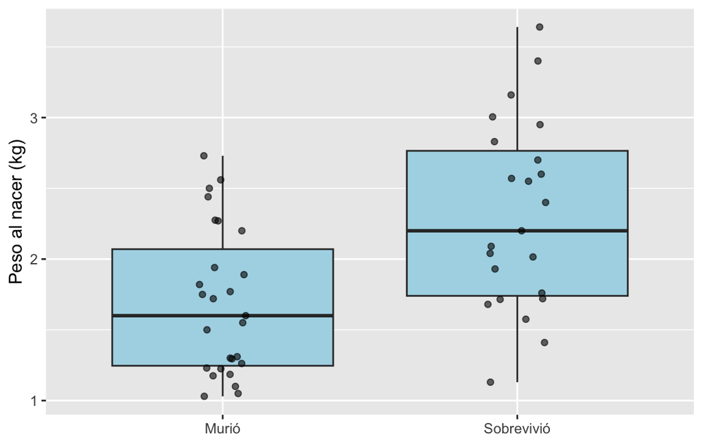

```r
# Dos capas: la caja resume y los puntos muestran a cada bebé.
# geom_jitter() mueve cada punto un poco a los lados para que no se encimen;
# height = 0 evita que se mueva hacia arriba o abajo, que cambiaría el peso.
ggplot(sirds, aes(x = desenlace, y = peso)) +
  geom_boxplot(fill = "lightblue", outlier.shape = NA) + # sin puntos repetidos
  geom_jitter(width = 0.1, height = 0, alpha = 0.6) +
  labs(x = NULL, y = "Peso al nacer (kg)")
```

```r
tapply(sirds$peso, sirds$desenlace, median)
```

```
     Murió Sobrevivió
       1.6        2.2
```

Los bebés que murieron pesaban menos (mediana de 1.60 kg contra 2.20 kg). Pero los dos grupos **se enciman**: hubo bebés pequeños que sobrevivieron y bebés grandes que murieron. El peso solo no decide.

### Endorfina beta en corredores

Concentración de endorfina beta en plasma (pmol/l) en tres grupos de 11 corredores: los que terminaron una carrera, medidos **antes** y **después**, y otros once que **colapsaron** al final.

```r
endorfina <- data.frame(
  grupo = rep(c("Terminó: antes", "Terminó: después", "Colapsó: después"),
              each = 11),
  valor = c(4.3, 4.6, 5.2, 5.2, 6.6, 7.2, 8.4, 9.0, 10.4, 14.0, 17.8,
            29.6, 25.1, 15.5, 29.6, 24.1, 37.8, 20.2, 21.9, 14.2, 34.6, 46.2,
            66, 72, 79, 84, 102, 110, 123, 144, 162, 169, 414)
)

# Sin esto, ggplot2 ordena los grupos alfabéticamente.
# factor() con levels fija el orden en que se escribieron.
endorfina$grupo <- factor(endorfina$grupo,
                          levels = c("Terminó: antes", "Terminó: después",
                                     "Colapsó: después"))
```

Fuente: Dale *et al.* (1987), en The Open University, OpenLearn, sección 2.4.

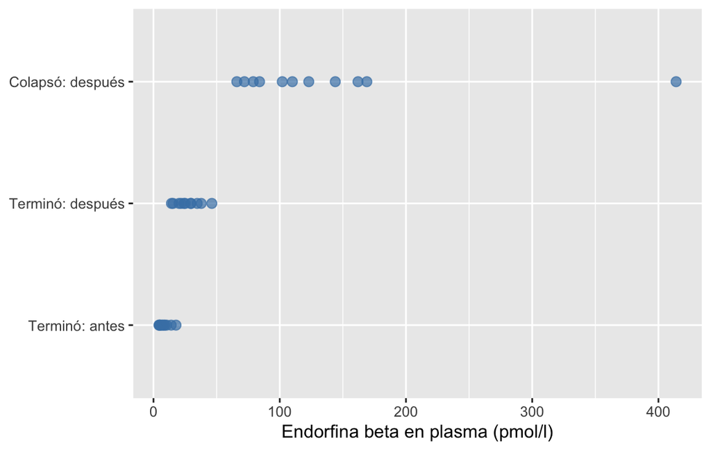

```r
ggplot(endorfina, aes(x = valor, y = grupo)) +
  geom_point(size = 2.5, alpha = 0.7, color = "steelblue") +
  labs(x = "Endorfina beta en plasma (pmol/l)", y = NULL)
```

**Pregunta:** en el grupo que colapsó, ¿qué resume mejor el centro: la **media** o la **mediana**? Decide viendo la gráfica y después calcula las dos con `tapply()`.

**TipRespuesta: la mediana; un solo corredor jala la media**

```r
tapply(endorfina$valor, endorfina$grupo, mean)
tapply(endorfina$valor, endorfina$grupo, median)
```

| Grupo | Media | Mediana |
| --- | --- | --- |
| Terminó: antes | 8.4 | 7.2 |
| Terminó: después | 27.2 | 25.1 |
| Colapsó: después | 138.6 | 110.0 |

En los que colapsaron, el valor de **414** sube la media muy por encima de la mediana. Es la misma robustez que se vio con el peso al nacer.

Un detalle de estos datos: los dos primeros grupos son **las mismas personas** (datos pareados). En la fuente cada columna viene ordenada de menor a mayor, así que ya no se sabe qué valor de «antes» va con cuál de «después». Por eso se grafican como grupos.

## 8. Dos variables numéricas: la gráfica de dispersión

Con dos variables numéricas, cada fila es **un punto**.

### Alcohol y muertes por cirrosis

```r
alcohol <- data.frame(
  pais = c("Francia", "Italia", "Alemania Occ.", "Austria", "Bélgica",
           "Estados Unidos", "Canadá", "Inglaterra y Gales", "Suecia", "Japón",
           "Países Bajos", "Irlanda", "Noruega", "Finlandia", "Israel"),
  litros = c(24.7, 15.2, 12.3, 10.9, 10.8, 9.9, 8.3, 7.2, 6.6, 5.8, 5.7, 5.6,
             4.2, 3.9, 3.1),
  muertes = c(46.1, 23.6, 23.7, 7.0, 12.3, 14.2, 7.4, 3.0, 7.2, 10.6, 3.7,
              3.4, 4.3, 3.6, 5.4)
)
```

Consumo anual de alcohol (litros por persona) y muertes por cirrosis y alcoholismo (por 100 000 habitantes) en 15 países. Fuente: Osborn (1979), en The Open University, OpenLearn, sección 2.5.

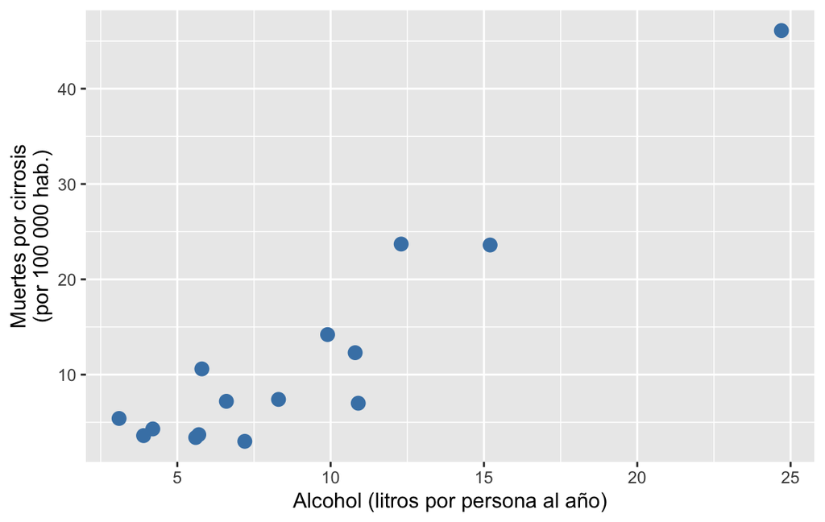

```r
ggplot(alcohol, aes(x = litros, y = muertes)) +
  geom_point(size = 3, color = "steelblue") +
  labs(x = "Alcohol (litros por persona al año)",
       y = "Muertes por cirrosis\n(por 100 000 hab.)") # \n parte la línea
```

**Pregunta:** ¿qué país se sale del patrón? Intenta resaltarlo tú antes de abrir la respuesta.

**TipRespuesta: Francia**

Francia bebe y muere por cirrosis mucho más que los demás. Para resaltarla, se crea una columna que diga si cada fila es Francia (`TRUE`) o no (`FALSE`), y esa columna se mapea al color:

```r
# == compara cada país con "Francia": da TRUE solo en la primera fila
alcohol$es_francia <- alcohol$pais == "Francia"

ggplot(alcohol, aes(x = litros, y = muertes, color = es_francia)) +
  geom_point(size = 3) +
  labs(x = "Alcohol (litros por persona al año)",
       y = "Muertes por cirrosis\n(por 100 000 hab.)",
       color = "¿Es Francia?")
```

Y para ver qué pasa **sin** Francia, se quita su fila con `!=` («distinto de»):

```r
sin_francia <- alcohol[alcohol$pais != "Francia", ]

ggplot(sin_francia, aes(x = litros, y = muertes)) +
  geom_point(size = 3, color = "steelblue")
```

Sin Francia la relación sigue (a más alcohol, más muertes), pero **más débil**. Un solo punto puede cambiar la conclusión.

### Peso del cuerpo y del cerebro: la escala logarítmica

La tabla `Animals` del paquete `MASS` trae el peso del cuerpo (kg) y del cerebro (g) de 28 especies, del ratón al braquiosaurio (Jerison, 1973).

```r
# Animals guarda el nombre de cada especie como nombre de fila, no como
# columna. rownames() lo saca y se guarda en una columna nueva.
animales <- Animals
animales$especie <- rownames(Animals)
head(animales) # las primeras seis filas
```

```
                    body brain         especie
Mountain beaver     1.35   8.1 Mountain beaver
Cow               465.00 423.0             Cow
Grey wolf          36.33 119.5       Grey wolf
Goat               27.66 115.0            Goat
Guinea pig          1.04   5.5      Guinea pig
Dipliodocus     11700.00  50.0     Dipliodocus
```

**Pregunta:** con la gráfica del bloque siguiente, ¿se puede decir algo de la relación entre los dos pesos?

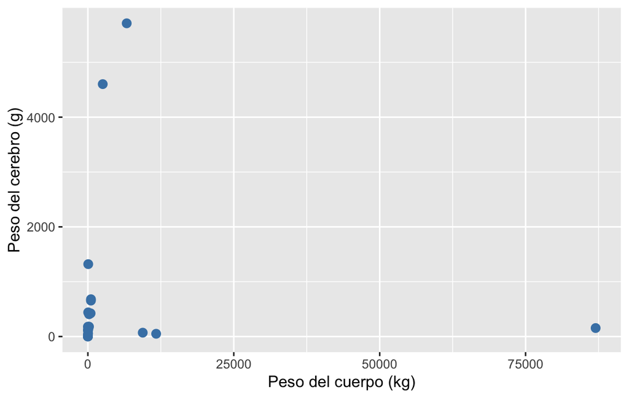

```r
ggplot(animales, aes(x = body, y = brain)) +
  geom_point(size = 2.5, color = "steelblue") +
  labs(x = "Peso del cuerpo (kg)", y = "Peso del cerebro (g)")
```

**TipRespuesta: casi nada, hasta cambiar la escala**

El ratón pesa 23 g y el braquiosaurio 87 toneladas: con una escala normal, casi todas las especies quedan en una esquina.

En escala **logarítmica**, cada marca del eje vale **diez veces** la anterior (1, 10, 100, 1000…), y los datos que van de gramos a toneladas se reparten. Se pide con `scale_x_log10()` y `scale_y_log10()`; córrelo en el bloque siguiente.

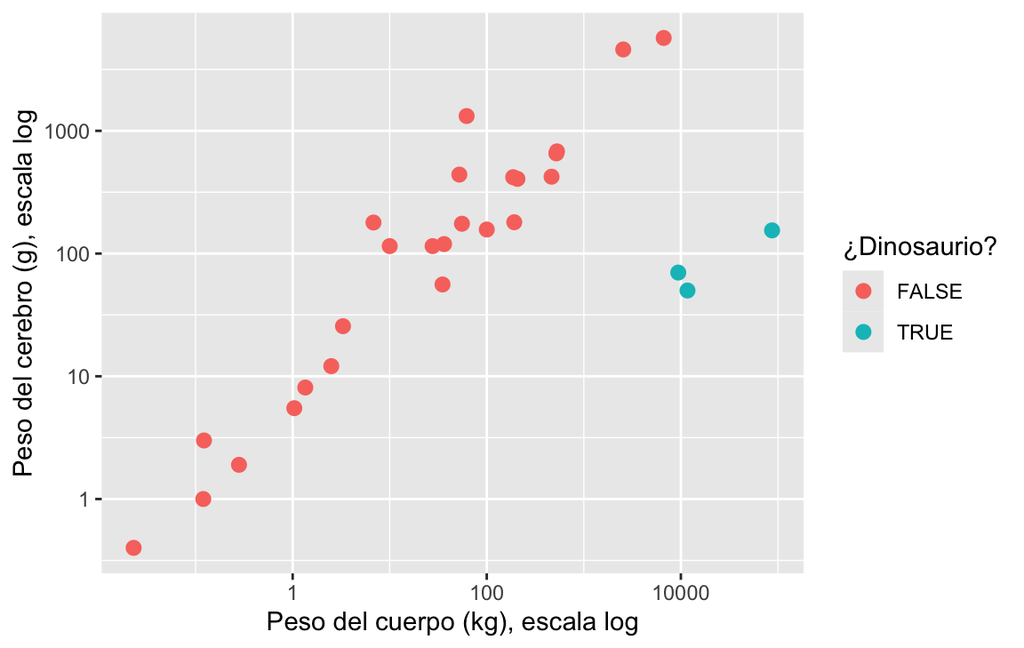

```r
# Una columna TRUE / FALSE: ¿la especie es uno de los tres dinosaurios?
# (Así vienen escritos en la tabla; «Dipliodocus» trae una i de más.)
animales$dinosaurio <- animales$especie %in%
  c("Dipliodocus", "Triceratops", "Brachiosaurus")

ggplot(animales, aes(x = body, y = brain, color = dinosaurio)) +
  geom_point(size = 2.5) +
  scale_x_log10() + # eje x en escala logarítmica
  scale_y_log10() + # eje y en escala logarítmica
  labs(x = "Peso del cuerpo (kg), escala log",
       y = "Peso del cerebro (g), escala log",
       color = "¿Dinosaurio?")
```

Aparece el patrón: a más cuerpo, más cerebro. Y aparecen las excepciones: los **tres dinosaurios**, con cerebros pequeños para su cuerpo. Los mismos datos, otra escala, **otra conclusión**.

## Para terminar la sesión

Un artículo, hipotético, reporta el tiempo de hospitalización como **media ± desviación estándar = 6 ± 9 días**.

¿Qué dice eso de la forma de la distribución, y qué resumen habría sido mejor?

**TipRespuesta: la distribución tiene sesgo a la derecha**

Los días de hospitalización **no pueden ser negativos**. Si la desviación estándar (9) es mayor que la media (6), es porque unos pocos pacientes estuvieron **muchísimos días** y jalan la media y la dispersión hacia arriba.

Habría sido mejor reportar **mediana y rango intercuartílico**, y mostrar un **histograma**.

### Lo que se practicó hoy

- Para comparar categorías, **barras ordenadas** (`reorder()`) antes que pastel (`coord_polar()`); nunca 3D, y las barras **desde cero**.
- El **centro** se resume con `mean()` o `median()`; la **dispersión**, con `sd()` o `IQR()`. `summary()` da casi todo de una vez.
- Con valores extremos o sesgo, **mediana y rango intercuartílico**.
- El **histograma** muestra la forma; la **caja** compara grupos (y `tapply()` da sus números); la **dispersión** relaciona dos números.
- La **escala** (`scale_x_log10()`) y el **eje** (`coord_cartesian()`) pueden cambiar la conclusión.

## Referencias

- Cleveland, W. S. y McGill, R. (1984). Graphical perception. *Journal of the American Statistical Association*, 79(387), 531–554.
- Diez, D., Çetinkaya-Rundel, M. y Barr, C. (2019). *OpenIntro Statistics* (4.ª ed.), sección 2.1. https://www.openintro.org/book/os/
- Sturges, H. A. (1926). The choice of a class interval. *Journal of the American Statistical Association*, 21(153), 65–66.
- The Open University. *Exploring data: graphs and numerical summaries*. OpenLearn. Tablas de centrales nucleares, fuerza laboral, SIRDS, endorfina, alcohol y tatuajes.
  - Dale, G. *et al.* (1987). Beta-endorphin: a factor in «fun run» collapse? *British Medical Journal*, 294, 1004.
  - Lunn, A. D. y McNeil, D. R. (1988). *The SPIDA Manual*. Statistical Computing Laboratory.
  - Osborn, J. F. (1979). *Statistical Exercises in Medical Research*. Blackwell.
  - van Vliet, P. K. y Gupta, J. M. (1973). Sodium bicarbonate in idiopathic respiratory distress syndrome. *Archives of Disease in Childhood*, 48, 249–255.
- Tufte, E. R. (1983). *The Visual Display of Quantitative Information*. Graphics Press.
- Tukey, J. W. (1977). *Exploratory Data Analysis*. Addison-Wesley.
- `birthwt`: Hosmer, D. W. y Lemeshow, S. (1989). *Applied Logistic Regression*. Wiley. `Animals`: Jerison, H. J. (1973). *Evolution of the Brain and Intelligence*. Academic Press. Ambas en Venables, W. N. y Ripley, B. D. (2002). *Modern Applied Statistics with S*. Springer.